# 利用TOF中的$\gamma$峰，对TOF进行绝对刻度（找到飞行时间零点）

- 目的是将切线探测器修正成环形；
- 因为，实验上中子能量$E_n$与TOF关关联，及相同能量的中子，飞行相同的距离其时间相等。但本实验探测器由于式切线形状，相同能量中子由靶点到中心和两端的距离不同，这样TOF不仅与能量有关，还与距离有关。为此，需要TOF绝对的刻度，即修正探测器形状；
- 最终目的，TOF仅与能量相关，TOF直接代表能量；

## 打开root文件，继承tree中Brach。

```python
//%jsroot on
TCanvas *c1=new TCanvas("c1","c1");//创建画布

//声明branch变量
Double_t ctof,tof;
Int_t pid;
Double_t tu, td, x;

//打开root文件
TFile *ipf=new TFile("./tree.root");//打开ROOT文件
//得到tree的指针
TTree *tree=(TTree*)ipf->Get("tree");

//将tree中Branch与变量地址联系
tree->SetBranchAddress("ctof",&ctof);
tree->SetBranchAddress("tof",&tof);
tree->SetBranchAddress("pid",&pid);
tree->SetBranchAddress("tu",&tu);
tree->SetBranchAddress("td",&td);
tree->SetBranchAddress("x",&x);
```

## 模拟计算的TOF

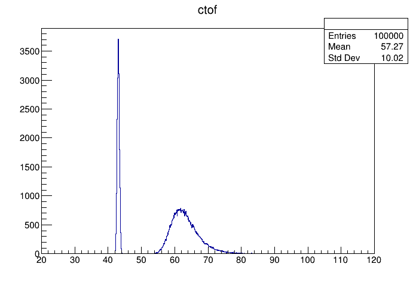

```python
tree->Draw("ctof>>(1000,20,120)");
c1->Draw();
```

## 查看$\gamma$的TOF与位置关联

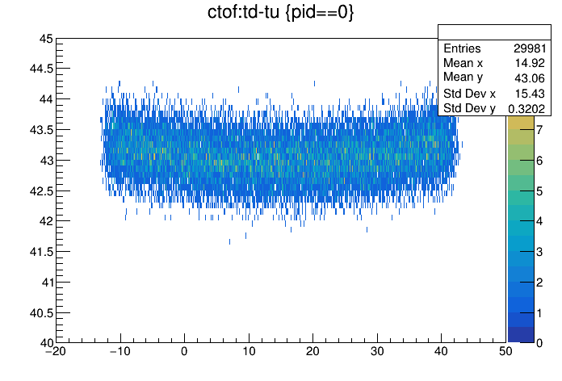

```python
tree->Draw("ctof:td-tu>>(2000,-20,50,50,40,45)","pid==0","colz");//加入条件,gamma
c1->Draw();
```

- 上图为$\gamma$事件，其速度为光速，定值；
- 两端高中间底，速度相同，越远离中心，飞行距离越长长，耗时越大；

## 逐事件提取$\gamma$的ctof事件，ctof进行飞行距离的修正

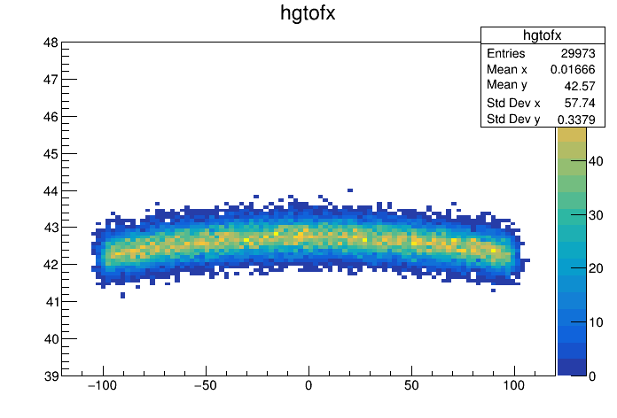

```python
TH2D *hgtofx=new TH2D("hgtofx","hgtofx",100,-120,120,100,39,48);
TH1D *hgctof=new TH1D("hgctof","hgctof",100,39,48);

//对事件进行遍历
Long64_t nentries=tree->GetEntries();
for(Long64_t jentry=0; jentry<nentries; jentry++)
    {
    tree->GetEntry(jentry);
    Double_t tx=3.742*(td-tu-14.915);  //时间差法刻度的位置
    if(ctof>42&& ctof<44.5)
      {
       Double_t d=TMath::Sqrt(502.5*502.5+tx*tx);//考虑了探测器的厚度的飞行距离
       Double_t ctofa=(ctof)/d*500.;//不同距离的tof统一修正到500 cm
       hgtofx->Fill(tx,ctofa);
       if(abs(tx)<5) hgctof->Fill(ctof);//挑出打在探测器中心的事件
      }
    }
hgtofx->Draw("colz");
c1->Draw();
```

- 修正之后发现依然与位置相关，修正后（$TOFc=\frac{TOF}{d_x}*d_0$）两端飞行时间比中间小;
- 意味着两端修正过大？？？

## 为修正offset的影响，首先得到$\gamma$打在探测器中心时的TOF值

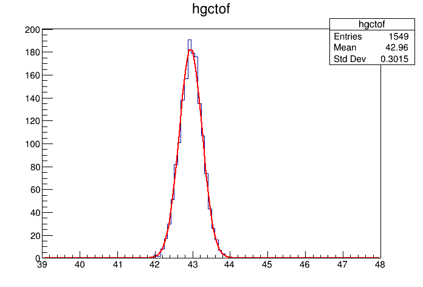

```
 FCN=5.9184 FROM MIGRAD    STATUS=CONVERGED      58 CALLS          59 TOTAL
                     EDM=1.21945e-07    STRATEGY= 1      ERROR MATRIX ACCURATE
  EXT PARAMETER                                   STEP         FIRST
  NO.   NAME      VALUE            ERROR          SIZE      DERIVATIVE
   1  Constant     1.83370e+02   5.78633e+00   5.99719e-03  -1.00487e-04
   2  Mean         4.29564e+01   7.74609e-03   2.04832e-05   4.86895e-04
   3  Sigma        3.02451e-01   5.70756e-03   6.52101e-06  -7.91675e-02
```

```python
hgctof->Draw();
hgctof->Fit("gaus");
c1->Draw();
```

## TOF的绝对刻度

虽然光在塑闪传播时间可根据模拟得到，但电子学、线缆、PMT导致的offset成分无法确定。

### 确定offset(包含塑闪、电子学、PMT等因素）方法

```python
TH2D *hgtofcx=new TH2D("hgtofcx","corrected TOF",100,-120,120,100,15,19);//实验测量抽取的tof修正到500 cm（考虑offset）与位置关联
TH1D *htofc=new TH1D("htofc","htofc",200,0,100);//实验测量抽取的tof修正到500 cm，即考虑offset；
TH1D *htof=new TH1D("htof","htof",200,0,100);//模拟中真实的tof修正到500 cm
```

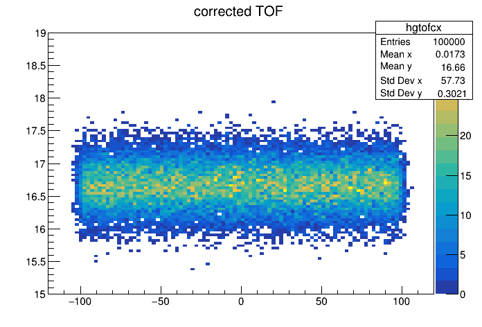

```python
//Long64_t nentries=tree->GetEntries();
for(Long64_t jentry=0; jentry<nentries; jentry++) {
    tree->GetEntry(jentry);
    Double_t tx=3.742*(td-tu-14.915);
    Double_t d=TMath::Sqrt(502.5*502.5+tx*tx);
    Double_t tofc=(ctof-26.2096)/d*500.;//normalized to 500cm
    hgtofcx->Fill(tx,tofc);//gamma hits the center of the det.
    htofc->Fill(tofc);
    htof->Fill(tof*500./d);
  }
hgtofcx->Draw("colz");//tofc与x之间无关联
c1->Draw();
```

- 为何不考虑offset影响会向下弯？
- 疑似$\frac{TOF}{d_x}*d_0$的修正，越偏离中心，修正越大；
- 当加入offset后有$（\frac{TOF}{d_x}-\frac{C}{d_x}）*d_0$，即在原有的修正基础上填加了一个附加项，而这个附加项使得越偏离中心位置，附加修正越小，弥补了之前边缘修正过大的问题。

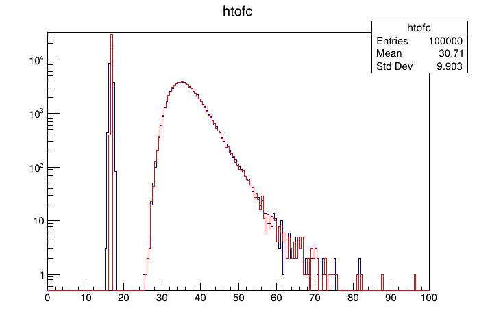

```python
c1->SetLogy();
htofc->Draw();//修正后的飞行时间谱
htof->SetLineColor(kRed);
htof->Draw("same");
c1->Draw();
```

实验测量抽取的tof修正到500 cm（考虑offset）与模拟中真实的tof修正到500 cm符合很好！

```python
ipf->Close();//关闭root文件
```

```python
!jupyter nbconvert homework1.1-3 --to html
```

```
[NbConvertApp] Converting notebook homework1.1-3.ipynb to html

[NbConvertApp] Writing 703805 bytes to homework1.1-3.html
```